# Illustration of Regularization

Tong Wang

October 2017

## Introduction

In this note, we illustrate the idea of regularization/shrikage using a very stylized example. The main setup is quite simple: the true function $y = f(x) = sin(\pi x)$ without noise. We will observe a data sample with **N=2** data points. Our task is to find a good model that fits the data and helps us predict out-of-sample.

We will consider 3 sets of models. Model 0 is the null model that predicts a constant; Model 1 is a linear model that fits a line with the data; and Model 2 is a regularized linear model, which fits a straight line on the two data points but shrinks the slope by a factor $\alpha \in [0, 1]$. We shall illustrate the impact of such shrinkage by comparing Model 0, 1, and 2. Note Model 2 reduces to Model 0 and 1 when $\alpha = 0$ and $\alpha = 1$, respectively.

## The Data Generating Model

Under the data generating model, $x \sim U[-1, 1]$ and $f(x) = \sin(\pi x)$. We could introduce noise $\epsilon \sim N(0, \sigma^2)$ and let $y = f(x) + \epsilon$. Let’s fix $\sigma=0$ for now; you can investigate its impact later. We generate $N=2$ data points $(x_1, y_1)$ and $(x_2, y_2)$ according to the model.

```r
set.seed(135790)
# static parameters
N <- 2  # sample size
x.min <- -1
x.max <- 1
sigma <- 0
# function for generating data
data.gen <- function(N=2) {
    x <- runif(n=N, min=x.min, max=x.max)
    f.x <- sin(pi * x)
    epsilon <- rnorm(n=N, mean=0, sd=sigma)
    y <- f.x + epsilon
    return(data.frame(x=x, y=y))
}
```

The true data generating model looks like this.

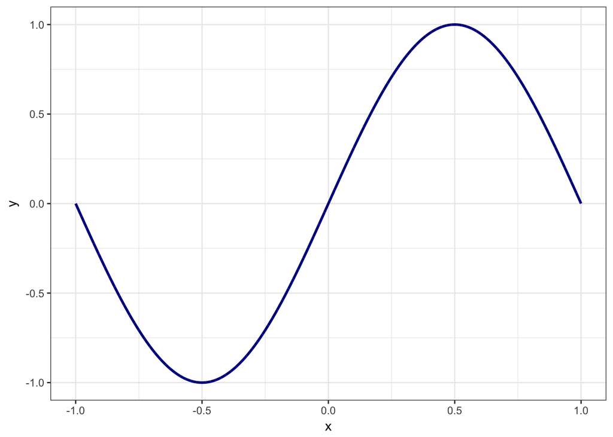

```r
ggplot() + geom_line(aes(x=x.out, y=f.x.out), color="darkblue", size=1) + labs(x="x", y="y") + theme_bw()
```

We will first generate a big out-of-sample dataset from the same population; later it will be needed to evaluate the out-of-sample performance.

```r
M <- 10000
x.out <- sort(runif(n=M, min=x.min, max=x.max))  # order the data points by x for easy plots
f.x.out <- sin(pi * x.out)
y.out <- f.x.out + rnorm(n=M, mean=0, sd=sigma)
```

## The Models

### Model 0: constant prediction

The $\mathcal{H}_0$ predicts a constant, and given a data sample, the best model in $\mathcal{H}_0$ will be predicting the mean $\bar{y}$, which is $(y_1 + y_2) / 2$ in the case of $N=2$.

```r
# function to generate constant prediction
h0 <- function(data) {
    return(c(mean(data$y), 0))  # return the intercept and slope as a vector (slope is zero)
}
```

### Model 1: linear prediction

The $\mathcal{H}_1$ fits a line based on the data. Given a data sample of size $2$, the best model will be the line connecting the two points.

```r
# function to generate line prediciton
h1 <- function(data) {
    b <- (data$y[1] - data$y[2]) / (data$x[1] - data$x[2])
    a <- data$y[1] - b * data$x[1]
    return(c(a, b))  # return the intercept and slope as a vector
}
```

### Model 2: linear prediction with shrinkage

The $\mathcal{H}_2$ fits a line based on the data with a shrinkage factor $\alpha$. The line goes through the mid-point of the two data points, and the slope is subject to shrinkage of factor $\alpha$.

```r
# function to generate line with shrinage
h2 <- function(data, alpha) {
    b <- alpha * (data$y[1] - data$y[2]) / (data$x[1] - data$x[2])
    a <- (data$y[1] + data$y[2]) / 2 - b * (data$x[1] + data$x[2]) / 2
    return(c(a, b))  # return the intercept and slope as a vector
}
```

## Comparison by simulation

Now let’s repeat the whole process of generating data and predictions many times (RUN=1000) and compare the models. For now, let’s fix $\alpha = 0.5$.

```r
RUN <- 1000
g0_D <- matrix(rep(0, RUN * 2), nrow=RUN, ncol=2)  # output of H0
g1_D <- matrix(rep(0, RUN * 2), nrow=RUN, ncol=2)  # output of H1
g2_D <- matrix(rep(0, RUN * 2), nrow=RUN, ncol=2)  # output of H2
for (run in 1:RUN){
    data <- data.gen()
    g0_D[run, ] <- h0(data)
    g1_D[run, ] <- h1(data)
    g2_D[run, ] <- h2(data, alpha=0.5)
}
```

## Quick visualization of the three types of hypothesis

We can plot the fitted models from the three models.

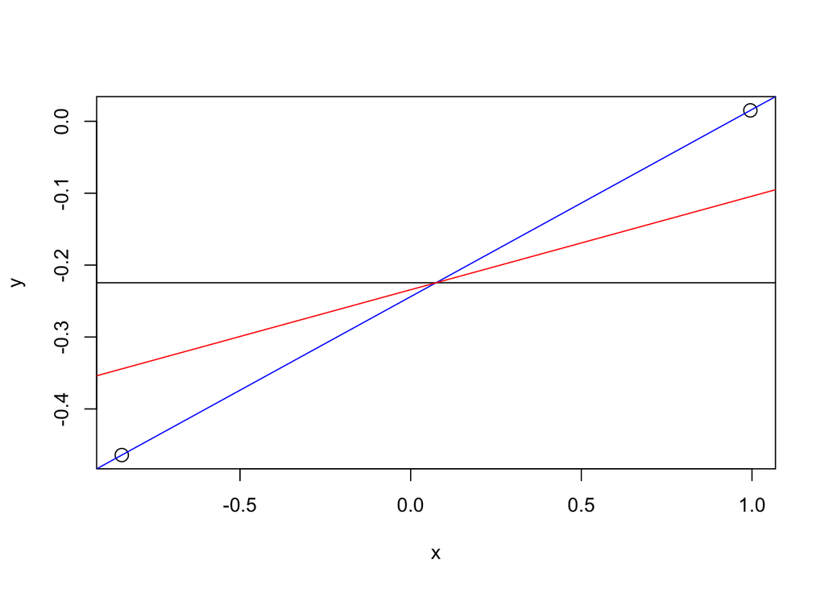

```r
plot(data, cex=1.5)
abline(a=g0_D[run, 1], b=g0_D[run, 2])  # H0 in black
abline(a=g1_D[run, 1], b=g1_D[run, 2], col="blue")  # H1 in blue
abline(a=g2_D[run, 1], b=g2_D[run, 2], col="red")  # H2 in red
```

### Individual Models

We can visualize the 1000 final model $g_0^{(D)}$, $g_1^{(D)}$, and $g_2^{(D)}$ together with the true function $f(x)$ (in blue).

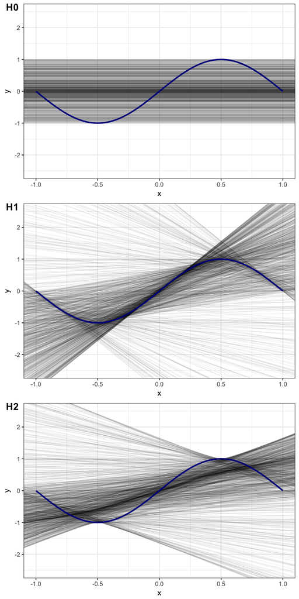

```r
x.lim <- c(x.min, x.max)
y.lim <- c(-2.5, 2.5)

plot0 <- ggplot() + geom_abline(intercept=g0_D[, 1], slope=g0_D[, 2], alpha=0.05) + geom_line(aes(x=x.out, y=f.x.out), color="darkblue", size=1) + labs(x="x", y="y") + coord_cartesian(ylim=y.lim, xlim=x.lim) + theme_bw()

plot1 <- ggplot() + geom_abline(intercept=g1_D[, 1], slope=g1_D[, 2], alpha=0.05) + geom_line(aes(x=x.out, y=f.x.out), color="darkblue", size=1) + labs(x="x", y="y") + coord_cartesian(ylim=y.lim, xlim=x.lim) + theme_bw()

plot2 <- ggplot() + geom_abline(intercept=g2_D[, 1], slope=g2_D[, 2], alpha=0.05) + geom_line(aes(x=x.out, y=f.x.out), color="darkblue", size=1) + labs(x="x", y="y") + coord_cartesian(ylim=y.lim, xlim=x.lim) + theme_bw()

cowplot::plot_grid(plot0, plot1, plot2, labels=c("H0", "H1", "H2"), align="h", ncol=1)
```

### Average Models

We can also visualize the “average” models $\bar{g}_0(x)$ and $\bar{g}_1(x)$ and also their “variability” over another bigger data sample “x.out”, which is to approximate the population. By definition, $\bar{g}(x) = \text{E}_D [g^{(D)}(x)]$, so we need to average out over $D$ while keeping the dependency on $x$. Similarly, we can measure variability over $D$ by $\text{SD}_D [g^{(D)}(x)]$.

```r
# for H0
g0_D_x <- g0_D %*% t(cbind(1, x.out))
g0_bar_x <- colMeans(g0_D_x)
g0_sd_x <- apply(g0_D_x, 2, sd)  # apply "sd" columnwise
# for H1
g1_D_x <- g1_D %*% t(cbind(1, x.out))
g1_bar_x <- colMeans(g1_D_x)
g1_sd_x <- apply(g1_D_x, 2, sd)  # apply "sd" columnwise
# for H2
g2_D_x <- g2_D %*% t(cbind(1, x.out))
g2_bar_x <- colMeans(g2_D_x)
g2_sd_x <- apply(g2_D_x, 2, sd)  # apply "sd" columnwise
```

With the above, we can visualize the “average” and “variability” as a function of $x$.

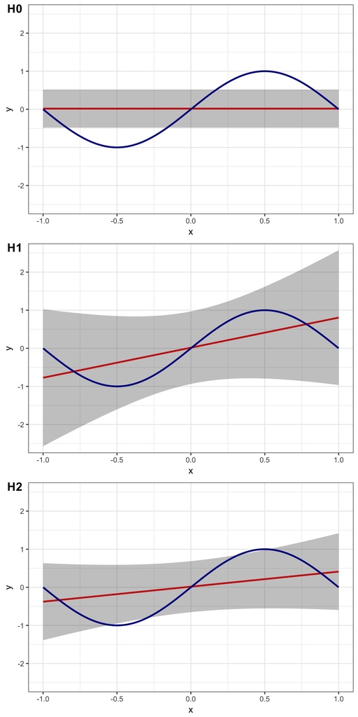

```r
plot0_bar <- ggplot() + geom_line(aes(x=x.out, y=g0_bar_x), color="red", size=1) + geom_ribbon(aes(x=x.out, ymin=g0_bar_x - g0_sd_x, ymax=g0_bar_x + g0_sd_x), alpha=0.3) + geom_line(aes(x=x.out, y=f.x.out), color="darkblue", size=1) + labs(x="x", y="y") + coord_cartesian(ylim=y.lim, xlim=x.lim) + theme_bw()

plot1_bar <- ggplot() + geom_line(aes(x=x.out, y=g1_bar_x), color="red", size=1) + geom_ribbon(aes(x=x.out, ymin=g1_bar_x - g1_sd_x, ymax=g1_bar_x + g1_sd_x), alpha=0.3) + geom_line(aes(x=x.out, y=f.x.out), color="darkblue", size=1) + labs(x="x", y="y") + coord_cartesian(ylim=y.lim, xlim=x.lim) + theme_bw()

plot2_bar <- ggplot() + geom_line(aes(x=x.out, y=g2_bar_x), color="red", size=1) + geom_ribbon(aes(x=x.out, ymin=g2_bar_x - g2_sd_x, ymax=g2_bar_x + g2_sd_x), alpha=0.3) + geom_line(aes(x=x.out, y=f.x.out), color="darkblue", size=1) + labs(x="x", y="y") + coord_cartesian(ylim=y.lim, xlim=x.lim) + theme_bw()

cowplot::plot_grid(plot0_bar, plot1_bar, plot2_bar, labels=c("H0", "H1", "H2"), align="h", ncol=1)
```

### Error Measures

Finally, we can calculate the Bias, Variance, and total MSE. Recall that
$$\text{Bias} = \text{E}_x \left[ (\bar{g}(x) - f(x))^2 \right];~~~~~ \text{Variance} = \text{E}_x \text{E}_D \left[ (g^{(D)}(x) - \bar{g}(x))^2 \right];~~~~~ \text{MSE} = \text{E}_x \text{E}_D \left[ (g^{(D)}(x) - y)^2 \right].$$

For $\mathcal{H}_0$,

```r
bias0 <- mean((g0_bar_x - f.x.out)^2)
variance0 <- mean((t(g0_D_x) - g0_bar_x)^2)
mse0 <- mean((t(g0_D_x) - y.out)^2)
```

and for $\mathcal{H}_1$ and $\mathcal{H}_2$,

```r
bias1 <- mean((g1_bar_x - f.x.out)^2)
variance1 <- mean((t(g1_D_x) - g1_bar_x)^2)
mse1 <- mean((t(g1_D_x) - y.out)^2)

bias2 <- mean((g2_bar_x - f.x.out)^2)
variance2 <- mean((t(g2_D_x) - g2_bar_x)^2)
mse2 <- mean((t(g2_D_x) - y.out)^2)
```

The final numbers are as follows.

| Hypothesis Set | Bias | Variance | Irreducible Error | MSE |
| --- | --- | --- | --- | --- |
| $\mathcal{H}_0$: constant | 0.503784 | 0.250214 | 5.551115110^{-17} | 0.753998 |
| $\mathcal{H}_1$: linear | 0.2033232 | 1.6569023 | 2.22044610^{-16} | 1.8602255 |
| $\mathcal{H}_2$: linear, $\alpha=0.5$ | 0.3021907 | 0.6362416 | 0 | 0.9384323 |

## Numerical optimization of the shrinkage factor $\alpha$

Now we enumerate many possible values of $\alpha$ in the range $[0, 1]$, repeat the above process of fitting a model for each $\alpha$, keep track of the resulted MSE, Bias, Variance of each model, and plot them out agaist $\alpha$.

```r
alphas <- seq(0, 1, 0.01)
alpha.num <- length(alphas)

RUN <- 1000
g2_D2 <- matrix(rep(0, RUN * 2 * alpha.num), nrow=RUN, ncol=2 * alpha.num)  # output of g2
# fit the lines and save the intercepts and slopes
for (run in 1:RUN){
    data <- data.gen()
    for (i in 1:alpha.num) {
        g2_D2[run, c(i * 2 - 1 , i * 2)] <- h2(data, alpha=alphas[i])
    }
}

# evaluate errors
result <- data.frame(alpha=alphas, bias=NA, variance=NA, mse=NA)
for (i in 1:alpha.num) {
    g2_D_x2 <- g2_D2[, c(i * 2 - 1 , i * 2)] %*% t(cbind(1, x.out))
    g2_bar_x2 <- colMeans(g2_D_x2)
    result[i, "bias"] <- mean((g2_bar_x2 - f.x.out)^2)
    result[i, "variance"] <- mean((t(g2_D_x2) - g2_bar_x2)^2)
    result[i, "mse"] <- mean((t(g2_D_x2) - y.out)^2)
}
```

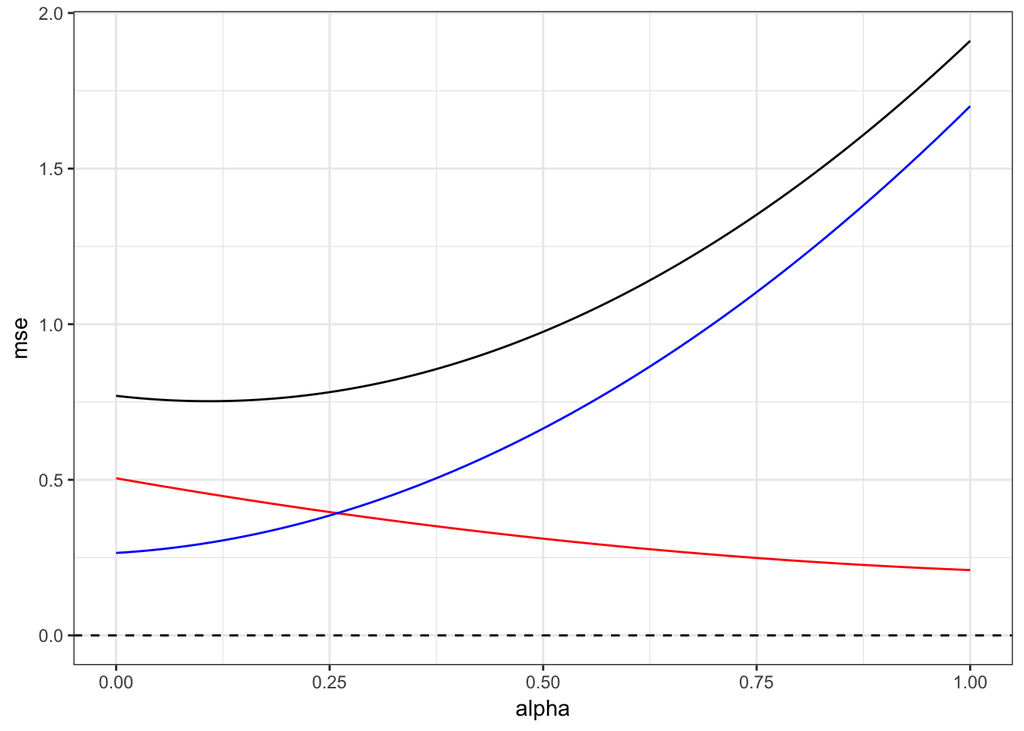

```r
ggplot(data=result) + geom_line(aes(x=alpha, y=mse)) + geom_line(aes(x=alpha, y=bias), color="red") + geom_line(aes(x=alpha, y=variance), color="blue") + geom_hline(yintercept=sigma^2, linetype="dashed") + theme_bw()
```

The best model turns out to be the following. You can run it and visualize what it does.

```r
result[which.min(result$mse),]
```

```
##    alpha      bias  variance       mse
## 12  0.11 0.4542399 0.2982958 0.7525357
```